# Hockey Graphs Data Sprint

Matthew Barlowe and Jason Baik

11/5/2017

For this project we’ll be looking at the difference in total offensive events split by whether the home team starts on the left side of the ice/coordinate system as it traditionally does or on the right side of the ice. The theory is that with the home team starting on the right side this creates two periods of what is know as the long change where more teams are apt to be caught changing lines because their bench is further from their defensive zone.

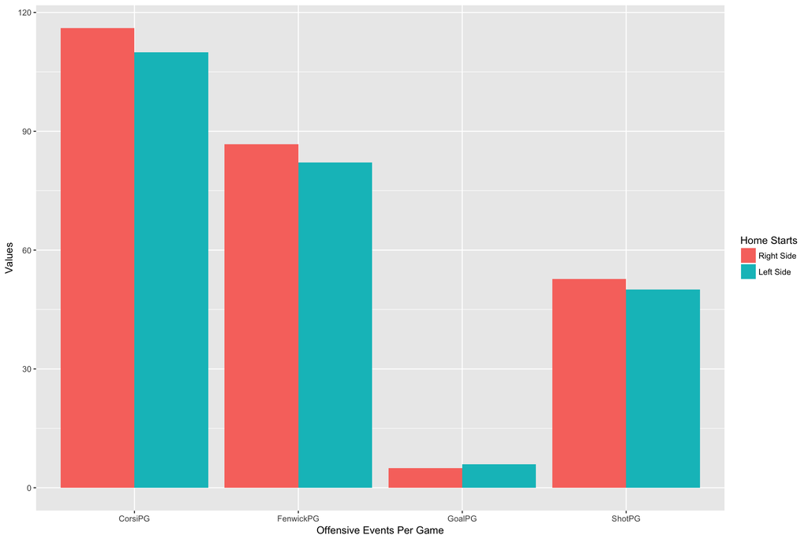

```r
#remove NAs
long_shift_data <- subset(final_data, !is.na(final_data$home_starts_left_side))

#summarise total offensive stats
game_summary <- long_shift_data %>% group_by(home_starts_left_side) %>%
    summarise(games = length(unique(game_id)),
              goals = length(which(type == 'goal')),
              shots = length(which(type == 'shot')),
              missed_shot = length(which(type == 'missed_shot')),
              blocked_shot = length(which(type == 'blocked_shot')))

#add offensive catgories per game to the game_summary dataframe
game_summary <- game_summary %>%
    mutate(GoalPG = goals/games,
           ShotPG = shots/games,
           MissPG = missed_shot/games,
           BlkPG = blocked_shot/games,
           CorsiPG = (goals + shots + missed_shot + blocked_shot)/games,
           FenwickPG = (goals + shots + missed_shot)/games )

#converts game_summary data from wide to long
game_summary_long <- game_summary %>%
    gather('GoalPG', 'ShotPG', 'CorsiPG', 'FenwickPG', key = 'events', value = 'value')

#plots offensive metircs per game
ggplot(data = game_summary_long) +
    geom_bar(aes(x = events, y = game_summary_long$value,
                 fill = home_starts_left_side),
             position = 'dodge', stat = 'identity') +
    ylab('Values') + xlab('Offensive Events Per Game') +
    scale_fill_discrete(labels = c('Right Side', 'Left Side'),
                       name = 'Home Starts')
```

As seen above the total amount of offensive metrics per game was higher for games where the home team started on the right side except for actual goals. Are these differences statistically sginificant though? Let’s find out.

```r
#prepare data for t test
game_grouped_df <- long_shift_data %>% group_by(game_id) %>%
    summarise(games = length(unique(game_id)),
              goals = length(which(type == 'goal')),
              shots = length(which(type == 'shot')),
              missed_shot = length(which(type == 'missed_shot')),
              blocked_shot = length(which(type == 'blocked_shot')))

#joins home_starts_left_side with dataframe containing stats by game to
#be able to subset vectors by home_starts_left_side remember this for future
#joins like this similar to problem I had in pands with baseball data
game_grouped_df <- inner_join(game_grouped_df,
                    long_shift_data[!duplicated(long_shift_data$game_id),
                                    c('game_id', 'home_starts_left_side')],
                              by = c('game_id'))

#creates Corsi and Fenwick events per game and then subsets them into seperate
#dataframes to create seperate vectors for the t tests
game_grouped_df <- game_grouped_df %>%
    mutate(Corsi = (goals + shots + missed_shot + blocked_shot)/games,
           Fenwick = (goals + shots + missed_shot)/games )

game_grouped_true <- subset(game_grouped_df,
                            game_grouped_df$home_starts_left_side == 'True')

game_grouped_false <- subset(game_grouped_df,
                            game_grouped_df$home_starts_left_side == 'False')

dim(game_grouped_false)
```

```
## [1] 66  9
```

```r
dim(game_grouped_true)
```

```
## [1] 83  9
```

```r
#Runs t tests to determine if the difference in the means is statistically
#significant

t.test(game_grouped_true$Corsi, y = game_grouped_false$Corsi)
```

```
##
##  Welch Two Sample t-test
##
## data:  game_grouped_true$Corsi and game_grouped_false$Corsi
## t = -2.9132, df = 128.32, p-value = 0.004222
## alternative hypothesis: true difference in means is not equal to 0
## 95 percent confidence interval:
##  -10.31337  -1.97031
## sample estimates:
## mean of x mean of y
##  109.9036  116.0455
```

```r
t.test(game_grouped_true$Fenwick, y = game_grouped_false$Fenwick)
```

```
##
##  Welch Two Sample t-test
##
## data:  game_grouped_true$Fenwick and game_grouped_false$Fenwick
## t = -2.491, df = 132.12, p-value = 0.01398
## alternative hypothesis: true difference in means is not equal to 0
## 95 percent confidence interval:
##  -8.2434336 -0.9460516
## sample estimates:
## mean of x mean of y
##  82.13253  86.72727
```

```r
t.test(game_grouped_true$shots, y = game_grouped_false$shots)
```

```
##
##  Welch Two Sample t-test
##
## data:  game_grouped_true$shots and game_grouped_false$shots
## t = -1.772, df = 136.88, p-value = 0.07862
## alternative hypothesis: true difference in means is not equal to 0
## 95 percent confidence interval:
##  -5.5726375  0.3053867
## sample estimates:
## mean of x mean of y
##  50.04819  52.68182
```

```r
t.test(game_grouped_true$goals, y = game_grouped_false$goals)
```

```
##
##  Welch Two Sample t-test
##
## data:  game_grouped_true$goals and game_grouped_false$goals
## t = 2.6831, df = 145.31, p-value = 0.00814
## alternative hypothesis: true difference in means is not equal to 0
## 95 percent confidence interval:
##  0.2531446 1.6690898
## sample estimates:
## mean of x mean of y
##  5.915663  4.954545
```

Here we see that the average total sum of Corsi and Fenwick events are higher at a statistically significant level on a two tailed t test. Shots while are on average higher when the home team starts on the right fail to reject the null hypotheis that the true difference in the means is 0. Goals on the other hand go the other way and show that games where the home team starts on the left more goals are score on average than if the home team started on the right.

Another reason could be in the distributions of goals for each type of game.

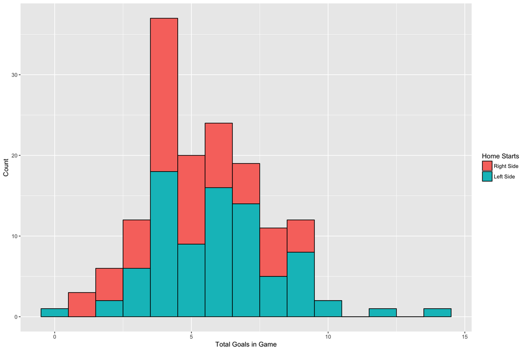

```r
ggplot(data = game_grouped_df) +
    geom_histogram(aes(x = goals, fill = home_starts_left_side), col = 'black',
                   binwidth = 1) +
    scale_fill_discrete(labels = c('Right Side',
                                   'Left Side'),
                                    name = 'Home Starts') +
    ylab('Count') + xlab('Total Goals in Game')
```

As shown in this graph there are some large outliers of 10, 12, and 14 goal games that could heavily skew the average up in a sample where the most common amount of goals scored in a game is 4. What if we removed the outliers and ran the t test again would the difference in the means of the two samples be statistically significant?

```r
sub_true <- subset(game_grouped_true, goals <= quantile(goals, .98))

t.test(sub_true$goals, y = game_grouped_false$goals)
```

```
##
##  Welch Two Sample t-test
##
## data:  sub_true$goals and game_grouped_false$goals
## t = 2.3145, df = 139.04, p-value = 0.02211
## alternative hypothesis: true difference in means is not equal to 0
## 95 percent confidence interval:
##  0.1145738 1.4578168
## sample estimates:
## mean of x mean of y
##  5.740741  4.954545
```

Nope the results are still statistically significant although the p-value is a lot larger. I think this lends credence to the idea that with more data, the averages between the two different data sets would be closer and eventually mirror the correlations between home starting side and Corsi.

In the end it shows that there may be more offense in games given the presence of two long shift changes, it just may not result in more actual goals as people would hope. At least its not shown in this data.